# RNAseq_github

Parul Kulshreshtha

## Introduction

This analysis examines RNA-seq data from matched tumor and normal tissue samples collected from 5 patients, yielding a total of 10 samples. The raw count matrix contains expression data for 19,701 genes across these samples.

Since each patient contributed both a tumor and normal sample, this represents a **paired experimental design**. This pairing is statistically advantageous because it allows us to control for patient-to-patient variability (due to age, genetics, lifestyle, etc.) and focus on the true biological differences between tumor and normal tissue within each individual.

### Analysis Objectives

1. Implement a complete RNA-seq analysis workflow from raw counts to differential expression results
2. Visualize normalized gene expression and sample relationships
3. Identify top differentially expressed genes between tumor and normal groups
4. Perform Gene Set Enrichment Analysis (GSEA) to identify dysregulated biological pathways

```r
# Load required packages
required_packages <- c(
  "DESeq2",
  "dplyr",
  "ggplot2",
  "fgsea",
  "data.table",
  "qusage",
  "BiocParallel",
  "knitr"
)
# Check if each package is installed; stop if missing
for (pkg in required_packages) {
  if (!requireNamespace(pkg, quietly = TRUE)) {
    stop(paste0("Package '", pkg, "' is not installed. Please install it first."))
  }
}
# Load all packages quietly and suppress output in knitted document
invisible(suppressMessages(suppressWarnings(
  lapply(required_packages, library, character.only = TRUE)
)))
# Register serial backend for BiocParallel
register(SerialParam())
```

Q1 Output the R workflow you use for the analysis from raw data to generating differential expression results.

```r
library(DESeq2)
library(dplyr)

# Read in the raw read counts and sample data
rawCounts <- read.delim("/Users/dr.parul/Downloads/assignment files/Data needed for the assignment-20251125/row_count_data.nodup.txt", header = TRUE, row.names = 1)
rawCounts <- ceiling(rawCounts)
sampleData <- read.delim("/Users/dr.parul/Downloads/assignment files/Data needed for the assignment-20251125/sample_groups.txt", header = TRUE, row.names = 1)

# Prepare Data & Filtering
sampleData <- sampleData[colnames(rawCounts), ]
sampleData$Patient <- factor(sampleData$Patient)
sampleData$Group <- factor(sampleData$Group)
sampleData$Group <- relevel(sampleData$Group, ref = "Normal")

# Create DESeq2 Object & Filter
dds <- DESeqDataSetFromMatrix(countData = rawCounts, colData = sampleData, design = ~ Patient + Group)
keep <- rowSums(counts(dds) >= 10) >= 5
dds <- dds[keep, ]

# Run the DESeq analysis
dds <- DESeq(dds)
# Extract and Order Results
res <- results(dds, contrast = c("Group", "Tumour", "Normal"))
res_ordered <- res[order(res$padj), ]

# Top 10 differentially expressed genes
top10_DE <- head(res_ordered, 10)

# Display with title
cat("Table: Top 10 Mostly Differentially Expressed Genes (Tumour vs Normal)\n\n")
```

```
## Table: Top 10 Mostly Differentially Expressed Genes (Tumour vs Normal)
```

```r
top10_DE ##Answer3
```

```
## log2 fold change (MLE): Group Tumour vs Normal
## Wald test p-value: Group Tumour vs Normal
## DataFrame with 10 rows and 6 columns
##          baseMean log2FoldChange     lfcSE      stat      pvalue        padj
##         <numeric>      <numeric> <numeric> <numeric>   <numeric>   <numeric>
## SLC6A15   513.915        3.74015  0.404053   9.25657 2.11107e-20 2.61836e-16
## DAPL1     807.842       -2.92773  0.333870  -8.76908 1.80137e-18 1.11712e-14
## PTGS2     266.049        4.26179  0.492004   8.66211 4.63103e-18 1.91462e-14
## SPINK6    275.583        7.78035  0.924420   8.41646 3.88024e-17 1.20317e-13
## CLEC3B   2409.200       -3.22911  0.386558  -8.35350 6.62705e-17 1.64391e-13
## KRT15    1043.598       -3.30996  0.401883  -8.23612 1.77887e-16 3.67721e-13
## TNS4     5597.100        1.91157  0.246288   7.76155 8.38958e-15 1.48651e-11
## LYVE1     137.423       -3.06655  0.416127  -7.36927 1.71563e-13 2.65987e-10
## PI16      610.086       -6.80714  0.934200  -7.28660 3.17877e-13 4.11244e-10
## CYBRD1    854.880       -2.72890  0.374802  -7.28091 3.31568e-13 4.11244e-10
```

This table answers question 3 but I will present it again below with ENSEMBL IDs.

Q2 Generate a boxplot of normalised gene expression across the 10 samples (e.g., boxplot (your normalised matrix), one plot with all 10 boxplots together, each representing one sample), and a PCA or MDS plot of the 10 samples together.

```r
## preparing the data for PCA and Boxplot
# Extract normalized counts
norm.counts <- counts(dds, normalized = TRUE)

# Export normalized counts to CSV
write.csv(norm.counts, file = "normalized_counts.csv", row.names = TRUE)

# Preview top 6 genes
head(norm.counts)
```

```
##        S02_Normal  S03_Normal  S05_Normal S06_Normal S10_Normal S02_Tumour
## CHAC1     0.00000    1.967858   0.8141559    0.00000   18.36927   56.58552
## GLRX    543.19896 1316.497185 359.8569084  168.53657  720.83561  106.88375
## MEFV     27.63367   25.582158   0.0000000   16.22277   36.73855   25.84771
## STXBP1   66.32080   84.617906  94.4420846  106.34928   76.64421  119.45831
## AKAP8L   21.31740   35.421449  21.9822093   40.55693   60.80863   18.16325
## AKR1C1   94.74400   47.228599  27.6813006   58.58223   65.24259  382.82547
##        S03_Tumour S05_Tumour S06_Tumour S10_Tumour
## CHAC1    7.141672   53.41418   52.94794   14.94555
## GLRX   184.663243   49.54359    0.00000  186.81942
## MEFV     0.000000   38.70593    0.00000   18.68194
## STXBP1  58.153618   68.89656   65.05033   74.72777
## AKAP8L   0.000000   31.73886    0.00000   29.89111
## AKR1C1  22.445256    0.00000    0.00000   16.19102
```

```r
# Variance stabilizing transformation (VST) ---
vsd <- vst(dds, blind = FALSE)

# Preview transformed counts for top 3 genes
head(assay(vsd), 3)
```

```
##       S02_Normal S03_Normal S05_Normal S06_Normal S10_Normal S02_Tumour
## CHAC1   5.826300   6.094588   5.999013   5.826300   6.636483   7.213023
## GLRX    9.348152  10.479500   8.865533   8.077336   9.697731   7.676883
## MEFV    6.813726   6.777686   5.826300   6.588815   6.957951   6.782439
##       S03_Tumour S05_Tumour S06_Tumour S10_Tumour
## CHAC1   6.335487   7.176279   7.170768   6.558837
## GLRX    8.164520   7.129628   5.826300   8.175756
## MEFV    5.826300   6.986360   5.826300   6.643172
```

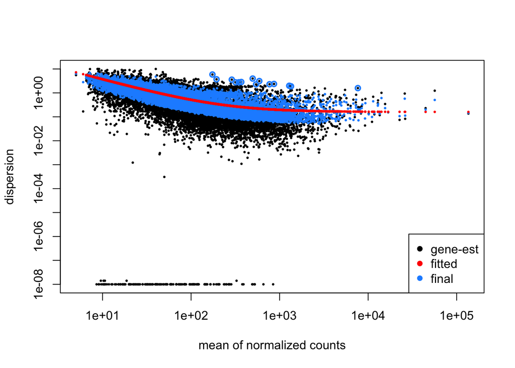

```r
## Plot dispersion estimates , this has been run only for QC
library(DESeq2)
plotDispEsts(dds)
```

The dispersion plot shows DESeq2 successfully estimated and shrank gene-wise dispersion values. The fitted trend (red line) follows the expected pattern of decreasing dispersion with increasing mean expression. Final dispersion estimates (blue) cluster well around the fitted trend, indicating reliable variance estimation for differential expression analysis.So, it is safe to continue our analysis.

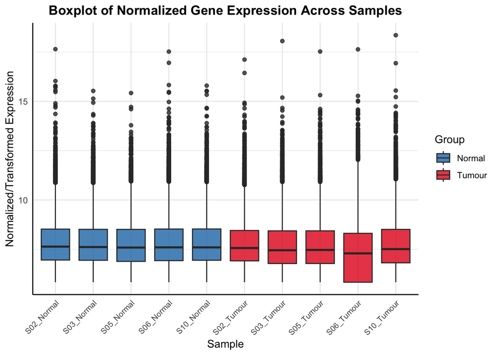

```r
##Answer 2a
## Prepare data for boxplot
library(reshape2)
boxplot_data <- as.data.frame(assay(vsd))        # use VST-transformed counts
boxplot_data$Gene <- rownames(boxplot_data)
boxplot_data <- melt(boxplot_data, id.vars = "Gene")
colnames(boxplot_data) <- c("Gene", "Sample", "Expression")
boxplot_data$Group <- sampleData[boxplot_data$Sample, "Group"]


ggplot(boxplot_data, aes(x = Sample, y = Expression, fill = Group)) +
    geom_boxplot(alpha = 0.8) +
    labs(title = "Boxplot of Normalized Gene Expression Across Samples",
         y = "Normalized/Transformed Expression",
         x = "Sample") +
    scale_fill_manual(values = c("Normal" = "#1f78b4", "Tumour" = "#e31a1c")) +
    theme_minimal() +
    theme(axis.text.x = element_text(angle = 45, hjust = 1, size = 8),
          plot.title = element_text(hjust = 0.5, face = "bold"),
          axis.line = element_line(color = "black"))
```

Interpretation: The boxplot shows that normalization was successful, with median expression levels consistent across all 10 samples.It seems S06 is an outlier. I will check the summary stats.

```r
# As the box plot for S06 looks different so I am checking the summary statistics for each sample
sample_stats <- data.frame(
  Sample = colnames(norm.counts),
  Mean = colMeans(norm.counts),
  Median = apply(norm.counts, 2, median),
  SD = apply(norm.counts, 2, sd),
  Min = apply(norm.counts, 2, min),
  Max = apply(norm.counts, 2, max),
  Q1 = apply(norm.counts, 2, quantile, 0.25),
  Q3 = apply(norm.counts, 2, quantile, 0.75)
)

# View the stats
sample_stats
```

```
##                Sample     Mean    Median        SD Min       Max       Q1
## S02_Normal S02_Normal 301.1588 101.06027 2316.1119   0 204911.54 36.31854
## S03_Normal S03_Normal 275.8641  98.39291  894.5377   0  47149.88 35.42145
## S05_Normal S05_Normal 252.0292  95.25624  732.4276   0  43769.84 31.75208
## S06_Normal S06_Normal 330.5961  96.43536 2336.6689   0 187946.21 34.24807
## S10_Normal S10_Normal 291.3526  96.28033 1136.1254   0  56723.05 35.47170
## S02_Tumour S02_Tumour 279.9671  92.21343 1715.1640   0 141859.19 33.53216
## S03_Tumour S03_Tumour 297.6994  79.57863 2584.9258   0 272612.94 25.50597
## S05_Tumour S05_Tumour 293.5746  81.28245 1930.5281   0 188427.44 25.54591
## S06_Tumour S06_Tumour 308.5801  63.53753 2151.9123   0 203350.35  0.00000
## S10_Tumour S10_Tumour 344.2077  85.93693 3371.5643   0 334568.67 27.40018
##                  Q3
## S02_Normal 262.1251
## S03_Normal 259.7573
## S05_Normal 258.9016
## S06_Normal 263.1694
## S10_Normal 264.1375
## S02_Tumour 245.5532
## S03_Tumour 240.7764
## S05_Tumour 241.1379
## S06_Tumour 213.3046
## S10_Tumour 259.0563
```

```r
# Check total counts per sample
total_counts <- colSums(rawCounts)
total_counts
```

```
## S02_Normal S03_Normal S05_Normal S06_Normal S10_Normal S02_Tumour S03_Tumour
##    4760619    1750477    3865843    4573375    5754227    4999546    3639389
## S05_Tumour S06_Tumour S10_Tumour
##    4724722    2539953    3463374
```

S06_Tumour has Q1 = 0 while all others are 25-36. Median: S06_Tumour = 63.5 (others: 79-101), Q3: S06_Tumour = 213.3 (others: 240-264), S06_Tumour has many more genes with zero/low expression, making it an outlier.

Interpretation:The boxplot shows that normalization was successful, with median expression levels consistent across all 10 samples. S06_Tumour showed greater variability in gene expression (Q1 = 0) compared to other samples, possibly indicating a distinct tumour phenotype. S06_Tumour displays greater variability with a lower Q1 value, indicating this sample has more genes with low/zero expression compared to other samples. Despite this variation, all samples were retained in the analysis as the paired design accounts for patient-specific differences.

```r
##Answer 2b
# B. PCA PLOT OF THE 10 SAMPLES (Question 2b)
# Getting PCA coordinates using VST-transformed counts
pcaData <- plotPCA(vsd, intgroup = c("Group", "Patient"), returnData = TRUE)
```

```
## using ntop=500 top features by variance
```

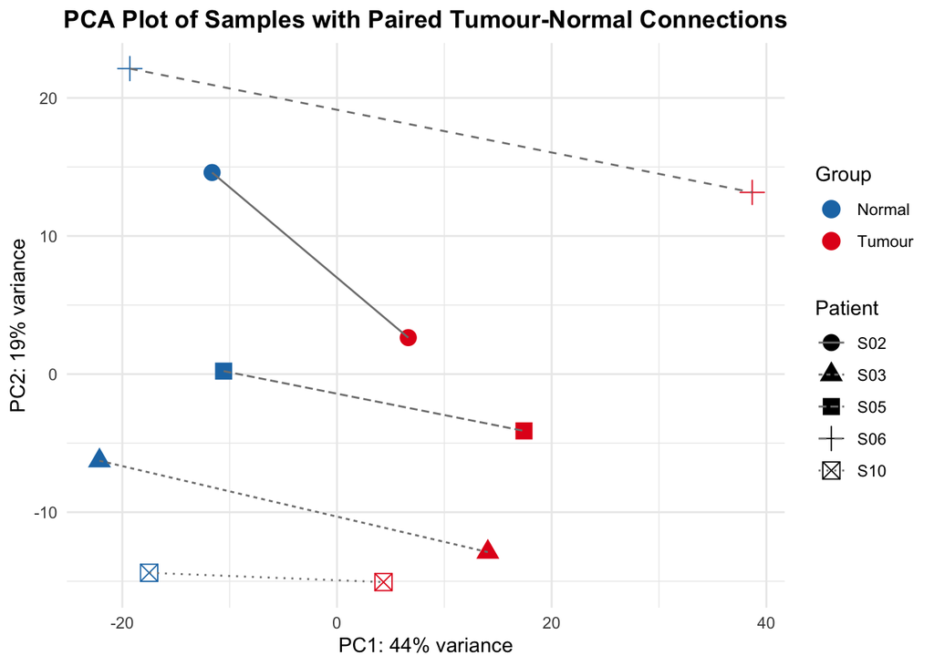

```r
percentVar <- round(100 * attr(pcaData, "percentVar"))

# Plot PCA with lines connecting paired samples
ggplot(pcaData, aes(x = PC1, y = PC2, color = Group, group = Patient)) +
    geom_point(size = 4, aes(shape = Patient)) +
    geom_line(aes(linetype = Patient), color = "grey50") +
    xlab(paste0("PC1: ", percentVar[1], "% variance")) +
    ylab(paste0("PC2: ", percentVar[2], "% variance")) +
    scale_color_manual(values = c("Normal" = "#1f78b4", "Tumour" = "#e31a1c")) +
    theme_minimal() +
    ggtitle("PCA Plot of Samples with Paired Tumour-Normal Connections") +
    theme(legend.position = "right", plot.title = element_text(hjust = 0.5, face = "bold"))
```

Interpretation:PCA shows clear separation between Normal (blue) and Tumour (red) samples along PC1 (44% variance), indicating distinct gene expression profiles between the two groups. The paired design is visible through connecting lines, with most patients showing consistent Normal→Tumour shifts toward positive PC1 values. S06 shows the largest difference between paired samples, with S06_Tumour being the most distinct sample (PC1 ~38), consistent with the outlier pattern observed in the boxplot.

```r
## Preparing file to be used later for GSEA with the sigs.df.annot column for gene symbols.
library(org.Hs.eg.db)
```

```r
# 1. Convert DESeq2 results to data.frame
res.df <- as.data.frame(res)

# 2. Extract gene symbols (rownames)
gene_symbols <- rownames(res.df)

# 3. Map SYMBOL -> ENSEMBL IDs
ensembl_ids <- mapIds(
    org.Hs.eg.db,
    keys = gene_symbols,
    keytype = "SYMBOL",
    column = "ENSEMBL",
    ifnotfound = NA,
    multiVals = "first"  # take the first match if multiple
)
# 4. Add gene symbols as last column
res.df$sigs.df.annot <- gene_symbols

# 5. Remove rows with missing ENSEMBL IDs
valid_idx <- !is.na(ensembl_ids)
res.df <- res.df[valid_idx, ]
ensembl_ids <- ensembl_ids[valid_idx]

# 6. Remove duplicate ENSEMBL IDs (keep the first occurrence)
unique_idx <- !duplicated(ensembl_ids)
res.df <- res.df[unique_idx, ]
ensembl_ids <- ensembl_ids[unique_idx]

# 7. Set ENSEMBL IDs as rownames
rownames(res.df) <- ensembl_ids

# 8. Remove ENSEMBL column if present
res.df$Ensembl_ID <- NULL

# 9. Save CSV
output_file <- "/Users/dr.parul/Downloads/assignment files/Data needed for the assignment-20251125/DE_TumourVSNormal_Paired_results_wGeneSymbol.csv"
write.csv(res.df, file = output_file)

cat("\n*** SUCCESS: File created with unique ENSEMBL rownames and sigs.df.annot column at:\n",
    normalizePath(output_file, mustWork = FALSE), "\n***\n")
```

```
##
## *** SUCCESS: File created with unique ENSEMBL rownames and sigs.df.annot column at:
##  /Users/dr.parul/Downloads/assignment files/Data needed for the assignment-20251125/DE_TumourVSNormal_Paired_results_wGeneSymbol.csv
## ***
```

Q3 List the top 10 mostly differentially expressed genes (based on adjusted p-values) between tumour and normal groups, with all their differential expression analysis statistics listed in one table.

```r
## Alternatively, I am presenting Answer 3 with ENSEMBL i.d.
# 1. Define the file path
file_path <- "/Users/dr.parul/Downloads/assignment files/Data needed for the assignment-20251125/DE_TumourVSNormal_Paired_results_wGeneSymbol.csv"

# 2. Load the DE results CSV (ENSEMBL IDs as rownames)
de_data <- read.csv(file_path, row.names = 1)

# 3. Remove any rows with missing adjusted p-values
de_data <- de_data[!is.na(de_data$padj), ]

# 4. Order genes by adjusted p-value (ascending = most significant first)
de_data_ordered <- de_data[order(de_data$padj), ]

# 5. Select top 10 most significant genes
top10_genes <- head(de_data_ordered, 10)

# 6. Display the top 10 genes table
top10_genes ##Answer 3 with ENSEMBL ids
```

```
##                  baseMean log2FoldChange     lfcSE      stat       pvalue
## ENSG00000072041  513.9151       3.740146 0.4040531  9.256569 2.111072e-20
## ENSG00000163331  807.8418      -2.927728 0.3338696 -8.769077 1.801373e-18
## ENSG00000073756  266.0492       4.261793 0.4920039  8.662112 4.631031e-18
## ENSG00000178172  275.5827       7.780349 0.9244204  8.416462 3.880243e-17
## ENSG00000163815 2409.1998      -3.229109 0.3865577 -8.353498 6.627054e-17
## ENSG00000171346 1043.5978      -3.309957 0.4018831 -8.236119 1.778865e-16
## ENSG00000131746 5597.1001       1.911574 0.2462876  7.761553 8.389576e-15
## ENSG00000133800  137.4226      -3.066553 0.4161270 -7.369271 1.715631e-13
## ENSG00000164530  610.0864      -6.807141 0.9342000 -7.286599 3.178768e-13
## ENSG00000071967  854.8797      -2.728904 0.3748024 -7.280913 3.315685e-13
##                         padj sigs.df.annot
## ENSG00000072041 2.618362e-16       SLC6A15
## ENSG00000163331 1.117121e-14         DAPL1
## ENSG00000073756 1.914623e-14         PTGS2
## ENSG00000178172 1.203166e-13        SPINK6
## ENSG00000163815 1.643907e-13        CLEC3B
## ENSG00000171346 3.677211e-13         KRT15
## ENSG00000131746 1.486513e-11          TNS4
## ENSG00000133800 2.659871e-10         LYVE1
## ENSG00000164530 4.112444e-10          PI16
## ENSG00000071967 4.112444e-10        CYBRD1
```

Although we are going to use the GMT file for downstream analysis, I have prepared this table of the top 10 mostly differentially expressed genes (based on adjusted p-values) between tumour and normal groups, with all their differential expression analysis statistics listed in one table.

```r
##loadign GMT file:C5 GP BP gene sets
library(qusage)
gmt.file <- read.gmt("/Users/dr.parul/Downloads/assignment files/Data needed for the assignment-20251125/c5.go.bp.v7.4.symbols.gmt")
```

```r
##redoing to prepare data without ENSEMBL to match C5 GP BP gene sets

# Preparing data for GSEA - Using Gene Symbols Directly (No ENSEMBL mapping)


# 1. Convert DESeq2 results to data.frame
res.df <- as.data.frame(res)

# 2. Add gene symbols as a column (from rownames)
res.df$GeneSymbol <- rownames(res.df)

# 3. Remove rows with NA adjusted p-values
res.df <- res.df[!is.na(res.df$padj), ]

# 4. Remove duplicate gene symbols (keep first occurrence)
res.df <- res.df[!duplicated(res.df$GeneSymbol), ]

# 5. Verify the data
cat("Number of genes:", nrow(res.df), "\n")
```

```
## Number of genes: 12403
```

```r
cat("Columns:", colnames(res.df), "\n")
```

```
## Columns: baseMean log2FoldChange lfcSE stat pvalue padj GeneSymbol
```

```r
head(res.df)
```

```
##         baseMean log2FoldChange     lfcSE       stat       pvalue         padj
## CHAC1   20.61862      5.1027410 1.4189250  3.5962022 3.228969e-04 7.126139e-03
## GLRX   363.68352     -3.0663688 0.6033363 -5.0823541 3.727857e-07 4.718021e-05
## MEFV    18.94127     -1.7565402 1.6814549 -1.0446550 2.961824e-01 5.305485e-01
## STXBP1  81.46609     -0.1788914 0.4638135 -0.3856968 6.997212e-01 8.440718e-01
## AKAP8L  25.98798     -2.2279853 1.2489375 -1.7839045 7.443918e-02 2.435424e-01
## AKR1C1  71.49405     -2.6746769 1.1260702 -2.3752310 1.753797e-02 1.028966e-01
##        GeneSymbol
## CHAC1       CHAC1
## GLRX         GLRX
## MEFV         MEFV
## STXBP1     STXBP1
## AKAP8L     AKAP8L
## AKR1C1     AKR1C1
```

4. Perform GSEA analysis against C5 GP BP gene sets (use the gene set file provided in RNA-seq practical) and list the top 10 mostly differentially regulated BP gene sets (based on adjusted p-values) with all the statistics listed in one table.

```r
## Answer 4
# GSEA Analysis using Gene Symbols
# Top 10 mostly differentially regulated GO Biological Process gene sets
# Ranked by adjusted p-value (padj)

library(fgsea)
library(qusage)
library(BiocParallel)

# Force single-threaded execution to avoid port errors
register(SerialParam())

#  Load GO BP gene set file
gmt.file <- read.gmt(
  "/Users/dr.parul/Downloads/assignment files/Data needed for the assignment-20251125/c5.go.bp.v7.4.symbols.gmt"
)

# Create ranked gene list from DESeq2 results
# Order genes by log2 fold change (descending)
res.df.ranked <- res.df[order(res.df$log2FoldChange, decreasing = TRUE), ]

# Create named vector: names = GeneSymbol, values = log2FoldChange
DE.ranks <- setNames(res.df.ranked$log2FoldChange,
                     res.df.ranked$GeneSymbol)

# Remove NA gene symbols and duplicates
DE.ranks <- DE.ranks[!is.na(names(DE.ranks))]
DE.ranks <- DE.ranks[!duplicated(names(DE.ranks))]

# Sanity check
cat("Number of genes in ranked list:", length(DE.ranks), "\n")
```

```
## Number of genes in ranked list: 12403
```

```r
cat("Top 5 upregulated genes:\n")
```

```
## Top 5 upregulated genes:
```

```r
print(head(DE.ranks, 5))
```

```
##    MMP10   SPINK6    CNGB1      OSM    MMP13
## 9.252084 7.780349 7.156698 6.903634 6.525303
```

```r
cat("Top 5 downregulated genes:\n")
```

```
## Top 5 downregulated genes:
```

```r
print(tail(DE.ranks, 5))
```

```
##    PRUNE2     CNTFR     ITIH5   SLC24A5   ANGPTL5
## -7.351654 -7.651132 -7.686442 -8.020092 -8.782138
```

```r
# 3. Run fgsea
set.seed(42)

fgseaRes <- fgseaMultilevel(
  pathways = gmt.file,
  stats    = DE.ranks,
  minSize  = 15,
  maxSize  = 500
)
# 4. Filter and rank results by adjusted p-value
cat("\n--- fgsea completed ---\n")
```

```
##
## --- fgsea completed ---
```

```r
cat("Total pathways tested:", nrow(fgseaRes), "\n")
```

```
## Total pathways tested: 3394
```

```r
cat("Significant pathways (padj < 0.05):",
    sum(fgseaRes$padj < 0.05, na.rm = TRUE), "\n")
```

```
## Significant pathways (padj < 0.05): 90
```

```r
# KEEP ONLY statistically significant pathways
fgseaRes <- fgseaRes[!is.na(fgseaRes$padj) & fgseaRes$padj < 0.05, ]

# Order by adjusted p-value
fgseaRes <- fgseaRes[order(fgseaRes$padj), ]

cat("\nTop 10 mostly differentially regulated BP gene sets:\n")
```

```
##
## Top 10 mostly differentially regulated BP gene sets:
```

```r
print(fgseaRes[1:10, c("pathway", "NES", "pval", "padj", "size")])
```

```
##                                                     pathway       NES
##                                                      <char>     <num>
##  1:                       GOBP_FATTY_ACID_METABOLIC_PROCESS -1.719215
##  2:              GOBP_MONOCARBOXYLIC_ACID_METABOLIC_PROCESS -1.614302
##  3:                            GOBP_LIPID_CATABOLIC_PROCESS -1.741635
##  4:                   GOBP_CELLULAR_LIPID_CATABOLIC_PROCESS -1.762091
##  5:                     GOBP_ORGANIC_ACID_CATABOLIC_PROCESS -1.733425
##  6:         GOBP_ORGANIC_HYDROXY_COMPOUND_METABOLIC_PROCESS -1.535534
##  7:                  GOBP_B_CELL_RECEPTOR_SIGNALING_PATHWAY  2.207321
##  8:                  GOBP_ORGANIC_ACID_BIOSYNTHETIC_PROCESS -1.601855
##  9: GOBP_FC_RECEPTOR_MEDIATED_STIMULATORY_SIGNALING_PATHWAY  1.990992
## 10:              GOBP_MONOCARBOXYLIC_ACID_CATABOLIC_PROCESS -1.771122
##             pval         padj  size
##            <num>        <num> <int>
##  1: 4.203996e-11 7.056407e-08   277
##  2: 3.031515e-11 7.056407e-08   447
##  3: 5.670621e-10 6.345425e-07   233
##  4: 3.805580e-08 2.555066e-05   171
##  5: 3.172513e-08 2.555066e-05   184
##  6: 1.549165e-07 8.667579e-05   371
##  7: 5.226024e-07 2.506252e-04    75
##  8: 9.182875e-07 3.853364e-04   222
##  9: 1.110892e-06 4.143626e-04   104
## 10: 2.059400e-06 6.913406e-04    99
```

```r
# --- 5. Save results ---
# Convert leadingEdge list to character for CSV export
fgseaRes_save <- as.data.frame(fgseaRes)
fgseaRes_save$leadingEdge <- sapply(
  fgseaRes_save$leadingEdge,
  paste,
  collapse = ", "
)

# Save FULL significant results
write.csv(
  fgseaRes_save,
  file = "/Users/dr.parul/Downloads/assignment files/Data needed for the assignment-20251125/PrerankedGSEA_GeneSymbols_TumourVsNormal_sigOnly_11Dec.csv",
  row.names = FALSE
)

cat("\n*** SUCCESS: Full significant results saved ***\n")
```

```
##
## *** SUCCESS: Full significant results saved ***
```

```r
# Save TOP 10 results (Answer to Question 4)
fgseaTop10 <- fgseaRes_save[1:10, ]

write.csv(
  fgseaTop10,
  file = "/Users/dr.parul/Downloads/assignment files/Data needed for the assignment-20251125/Top10_GOBP_GeneSets_Answer4_sigOnly_11Dec.csv",
  row.names = FALSE
)

cat("*** SUCCESS: Top 10 gene sets saved (Answer 4) ***\n")
```

```
## *** SUCCESS: Top 10 gene sets saved (Answer 4) ***
```

Answer 4:THIS IS THE LIST OF THE TOP 10 MOST DIFFERENTIALLY EXPRESSED BP GENESETS.

```r
# Identify Top 2 Upregulated and Top 2 Downregulated Pathways


# Separate by NES direction
upPathways <- fgseaRes[fgseaRes$NES > 0, ]
downPathways <- fgseaRes[fgseaRes$NES < 0, ]

# Order each by adjusted p-value
upPathways <- upPathways[order(upPathways$padj), ]
downPathways <- downPathways[order(downPathways$padj), ]

# Extract top 2 pathways from each
top2_up <- head(upPathways$pathway, 2)
top2_down <- head(downPathways$pathway, 2)

# Check the names
cat("Top 2 Upregulated BP gene sets:\n")
```

```
## Top 2 Upregulated BP gene sets:
```

```r
print(top2_up)
```

```
## [1] "GOBP_B_CELL_RECEPTOR_SIGNALING_PATHWAY"
## [2] "GOBP_FC_RECEPTOR_MEDIATED_STIMULATORY_SIGNALING_PATHWAY"
```

```r
cat("\nTop 2 Downregulated BP gene sets:\n")
```

```
##
## Top 2 Downregulated BP gene sets:
```

```r
print(top2_down)
```

```
## [1] "GOBP_FATTY_ACID_METABOLIC_PROCESS"
## [2] "GOBP_MONOCARBOXYLIC_ACID_METABOLIC_PROCESS"
```

```r
# Separate by NES direction
upPathways <- fgseaRes[fgseaRes$NES > 0, ]
downPathways <- fgseaRes[fgseaRes$NES < 0, ]

# Remove NA padj
upPathways <- upPathways[!is.na(upPathways$padj), ]
downPathways <- downPathways[!is.na(downPathways$padj), ]

# Order by padj (with NES as tie-breaker)
upPathways <- upPathways[order(upPathways$padj, -abs(upPathways$NES)), ]
downPathways <- downPathways[order(downPathways$padj, -abs(downPathways$NES)), ]

# Display top 4
cat("=== TOP 4 UPREGULATED PATHWAYS ===\n")
```

```
## === TOP 4 UPREGULATED PATHWAYS ===
```

```r
print(upPathways[1:4, c("pathway", "padj", "NES")])
```

```
##                                                                pathway
##                                                                 <char>
## 1:                              GOBP_B_CELL_RECEPTOR_SIGNALING_PATHWAY
## 2:             GOBP_FC_RECEPTOR_MEDIATED_STIMULATORY_SIGNALING_PATHWAY
## 3: GOBP_HUMORAL_IMMUNE_RESPONSE_MEDIATED_BY_CIRCULATING_IMMUNOGLOBULIN
## 4:                                GOBP_REGULATION_OF_B_CELL_ACTIVATION
##            padj      NES
##           <num>    <num>
## 1: 0.0002506252 2.207321
## 2: 0.0004143626 1.990992
## 3: 0.0010567977 2.168515
## 4: 0.0021030903 1.885938
```

```r
cat("\n=== TOP 4 DOWNREGULATED PATHWAYS ===\n")
```

```
##
## === TOP 4 DOWNREGULATED PATHWAYS ===
```

```r
print(downPathways[1:4, c("pathway", "padj", "NES")])
```

```
##                                       pathway         padj       NES
##                                        <char>        <num>     <num>
## 1:          GOBP_FATTY_ACID_METABOLIC_PROCESS 7.056407e-08 -1.719215
## 2: GOBP_MONOCARBOXYLIC_ACID_METABOLIC_PROCESS 7.056407e-08 -1.614302
## 3:               GOBP_LIPID_CATABOLIC_PROCESS 6.345425e-07 -1.741635
## 4:      GOBP_CELLULAR_LIPID_CATABOLIC_PROCESS 2.555066e-05 -1.762091
```

It was found that there was a tie between 2 pathways for position 1 among the downregulated genes as per padj values:GOBP_FATTY_ACID_METABOLIC_PROCESS and  
GOBP_MONOCARBOXYLIC_ACID_METABOLIC_PROCESS as they shared the same padj value 7.056407e-08, since this question is open to interpretation, so I am plotting all 3 proteins, with top 1 postion shared by GOBP_FATTY_ACID_METABOLIC_PROCESS and  
GOBP_MONOCARBOXYLIC_ACID_METABOLIC_PROCESS and second most downregulated by GOBP_LIPID_CATABOLIC_PROCESS. But if this was to be intrepreted to be as giving top2 pathways as per padj then the answer would be GOBP_FATTY_ACID_METABOLIC_PROCESS and  
GOBP_MONOCARBOXYLIC_ACID_METABOLIC_PROCESS. But my approach answers both the interpretations.

5.Produce GESA enrichment plots for the top 2 mostly upregulated BP gene sets (based on adjusted p-values) in tumour compared to normal, and the top 2 mostly downregulated BP gene sets in tumour compared to normal.

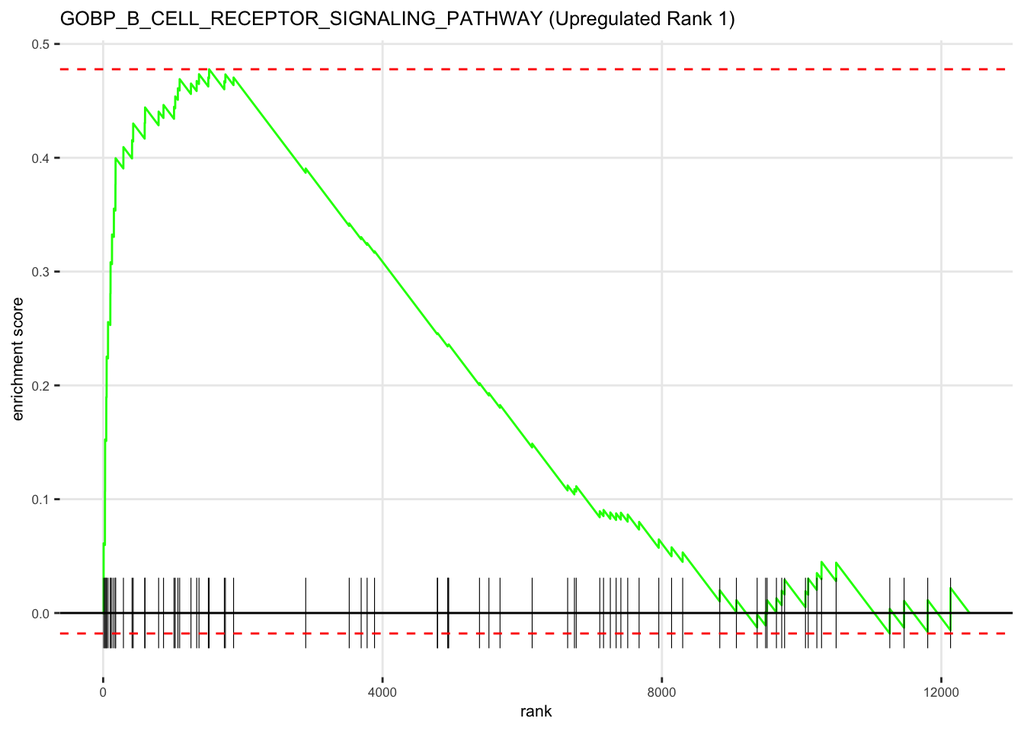

```r
# Answer 5: Enrichment Plots for Top 2 Up and Top 2 Down Pathways
##I found that there was a tie between 2 pathways for position 1 among the downregulated genes as per padj values:
##GOBP_FATTY_ACID_METABOLIC_PROCESS and GOBP_MONOCARBOXYLIC_ACID_METABOLIC_PROCESS with same padj value 7.056407e-08,
##since this question is open to interpretation:
## so I am plotting all 3 proteins, with top 1 postion shared by:
##GOBP_FATTY_ACID_METABOLIC_PROCESS and GOBP_MONOCARBOXYLIC_ACID_METABOLIC_PROCESS and second most downregulated by GOBP_LIPID_CATABOLIC_PROCESS.
## But if this was to be intrepreted to be as giving top2 pathways as per padj then the answer would be
##GOBP_FATTY_ACID_METABOLIC_PROCESS and GOBP_MONOCARBOXYLIC_ACID_METABOLIC_PROCESS. But my approach answers both the interpretations.

# Top 2 Upregulated in Tumour
EnPlotUp1 <- plotEnrichment(gmt.file[["GOBP_B_CELL_RECEPTOR_SIGNALING_PATHWAY"]], DE.ranks) +
  labs(title = "GOBP_B_CELL_RECEPTOR_SIGNALING_PATHWAY (Upregulated Rank 1)") +
  theme(text = element_text(size = 8))

EnPlotUp2 <- plotEnrichment(gmt.file[["GOBP_FC_RECEPTOR_MEDIATED_STIMULATORY_SIGNALING_PATHWAY"]], DE.ranks) +
  labs(title = "GOBP_FC_RECEPTOR_MEDIATED_STIMULATORY_SIGNALING_PATHWAY (Upregulated Rank 2)") +
  theme(text = element_text(size = 8))

# Top 2 Downregulated in Tumour (3 pathways due to tie at Rank 1)
EnPlotDown1a <- plotEnrichment(gmt.file[["GOBP_FATTY_ACID_METABOLIC_PROCESS"]], DE.ranks) +
  labs(title = "GOBP_FATTY_ACID_METABOLIC_PROCESS (Downregulated Rank 1 - Tied)") +
  theme(text = element_text(size = 8))

EnPlotDown1b <- plotEnrichment(gmt.file[["GOBP_MONOCARBOXYLIC_ACID_METABOLIC_PROCESS"]], DE.ranks) +
  labs(title = "GOBP_MONOCARBOXYLIC_ACID_METABOLIC_PROCESS (Downregulated Rank 1 - Tied)") +
  theme(text = element_text(size = 8))

EnPlotDown2 <- plotEnrichment(gmt.file[["GOBP_LIPID_CATABOLIC_PROCESS"]], DE.ranks) +
  labs(title = "GOBP_LIPID_CATABOLIC_PROCESS (Downregulated Rank 2)") +
  theme(text = element_text(size = 8))

# Display plots
EnPlotUp1
```

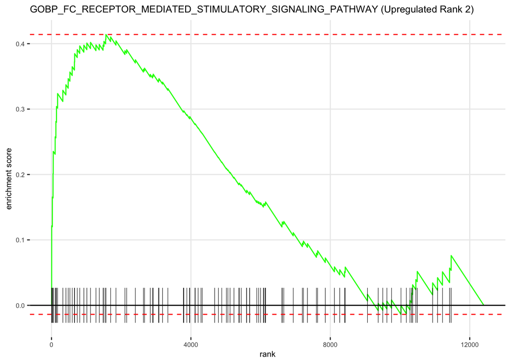

```r
EnPlotUp2
```

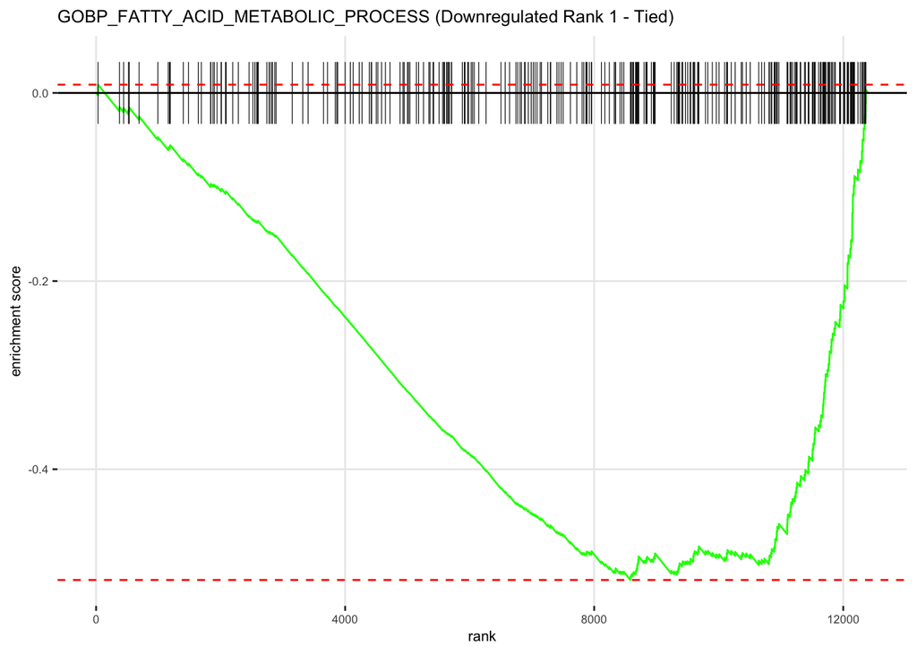

```r
EnPlotDown1a
```

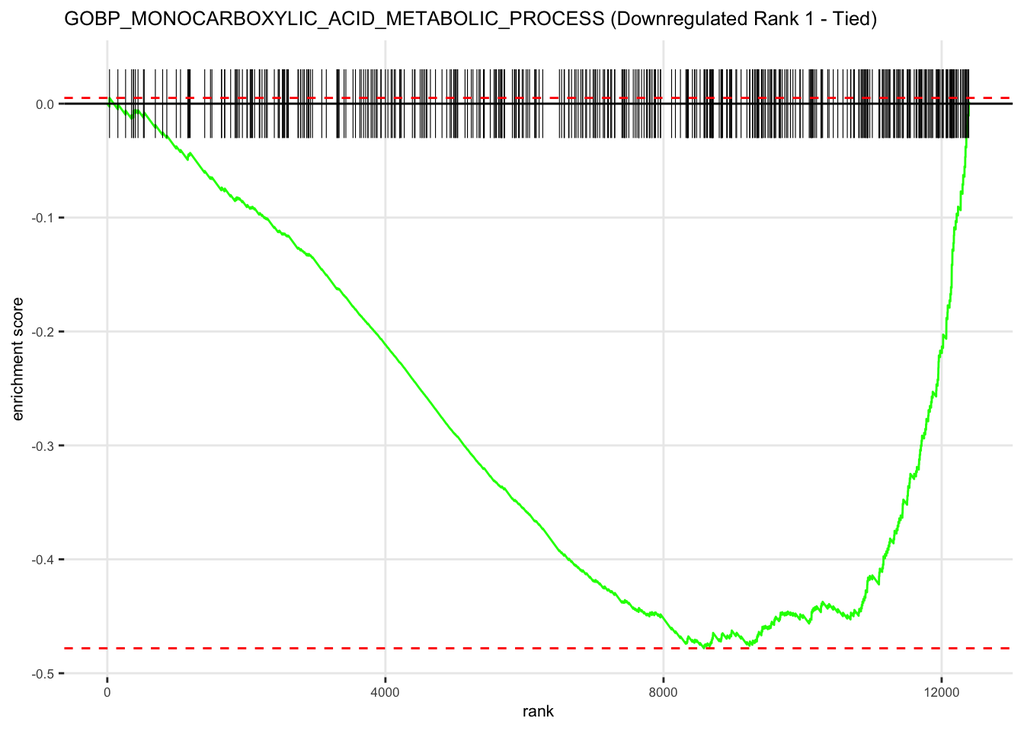

```r
EnPlotDown1b
```

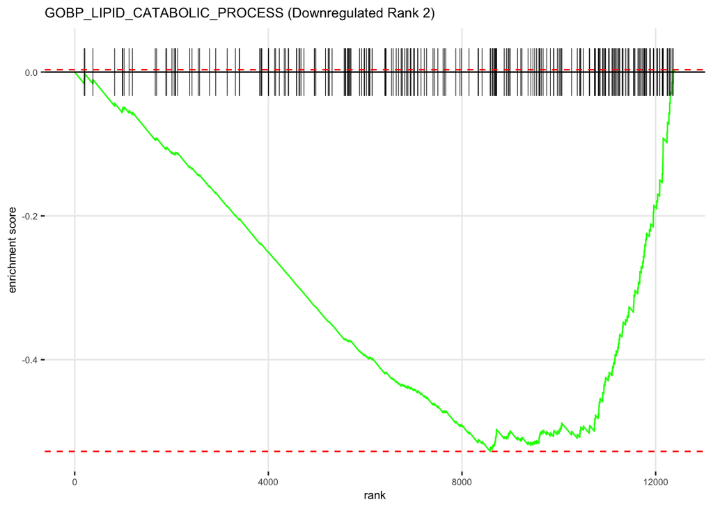

```r
EnPlotDown2
```